# TP4 – ANOVA à deux facteurs et Tests Non Paramétriques

- Montrer tout le code
- Cacher tout le code
- Voir les sources

Auteur·rice

HAMLIL Mohamed

Date de publication

2025

# Introduction

Ce TP couvre trois thèmes importants :

1. **Simulations et ANOVA à 1 facteur** : comprendre le comportement du test de Fisher par la simulation
2. **ANOVA à deux facteurs** : prendre en compte l’effet simultané de deux facteurs
3. **Tests non paramétriques** : alternatives quand l’hypothèse de normalité n’est pas vérifiée

# 1. Simulations et ANOVA à 1 facteur

## 1.1 Principe

Le test d’ANOVA (Fisher) teste l’égalité des moyennes entre groupes. La statistique est :

$$F_{obs} = \frac{CMM}{CME}$$

C’est un rapport entre la variance **due au modèle** et la variance **due aux erreurs**. Plus la variance de l’erreur est faible, plus on a de chances de rejeter l’égalité.

## 1.2 Modèle sans erreur

On suppose 3 niveaux avec 20 observations chacun et des moyennes 15, 20, 25 :

```r
x = c(rep(15, 20), rep(20, 20), rep(25, 20))
a = c(rep("a", 20), rep("b", 20), rep("c", 20))
```

Si on lance une ANOVA sur ce modèle **sans erreur** :

```r
anova(lm(x ~ a))
```

A anova: 2 × 5

|  | Df <int> | Sum Sq <dbl> | Mean Sq <dbl> | F value <dbl> | Pr(>F) <dbl> |
| --- | --- | --- | --- | --- | --- |
| a | 2 | 1.000000e+03 | 5.000000e+02 | 1.966637e+31 | 0 |
| Residuals | 57 | 1.449174e-27 | 2.542411e-29 | NA | NA |

R donne un avertissement : *les tests F d’ANOVA sur un ajustement pratiquement parfait ne sont pas fiables*. C’est logique : sans erreur, le test n’a pas de sens !

## 1.3 Introduction de l’erreur

On crée un vecteur d’erreurs normales centrées réduites :

```r
set.seed(42)
err = rnorm(60)
```

On ajoute l’erreur multipliée par un écart-type (commençons par 0.5) :

```r
xe = x + 0.5 * err
anova(lm(xe ~ a))
```

A anova: 2 × 5

|  | Df <int> | Sum Sq <dbl> | Mean Sq <dbl> | F value <dbl> | Pr(>F) <dbl> |
| --- | --- | --- | --- | --- | --- |
| a | 2 | 981.25762 | 490.628809 | 1471.204 | 8.849578e-50 |
| Residuals | 57 | 19.00882 | 0.333488 | NA | NA |

Avec un écart-type de 0.5, la p-value est très petite → rejet facile.

## 1.4 Fonction pour automatiser

```r
anovalue = function(x, a, sigma) {
  err = rnorm(length(x))
  xe = x + sigma * err
  return(anova(lm(xe ~ a))$Pr)
}
```

## 1.5 Exploration de l’effet de sigma

Faisons varier la valeur de `sigma` pour voir quand la p-value passe au-dessus de 5% :

```r
cat("sigma = 1 :", anovalue(x, a, 1), "\n")
cat("sigma = 5 :", anovalue(x, a, 5), "\n")
cat("sigma = 10 :", anovalue(x, a, 10), "\n")
cat("sigma = 15 :", anovalue(x, a, 15), "\n")
cat("sigma = 20 :", anovalue(x, a, 20), "\n")
```

```
sigma = 1 : 6.457851e-38 NA
sigma = 5 : 1.401194e-09 NA
sigma = 10 : 0.00149247 NA
sigma = 15 : 0.04803149 NA
sigma = 20 : 0.2232089 NA
```

> **Attention !** Puisque l’erreur est aléatoire, la p-value change à chaque appel. Près du seuil de 5%, relancez plusieurs fois pour observer les fluctuations.

> **Morale :** Voilà, vous savez pondre des études bidons maintenant ! C’est une leçon sur l’importance de ne pas p-hacker ses résultats.

# 2. ANOVA à deux facteurs

## 2.1 Données de dureté de mèche

### Contexte

On compare la vitesse de pénétration de **4 marques de mèches** en acier sur **5 types de dureté** d’acier. Les temps sont mesurés en secondes.

C’est une **classification à deux entrées** (mesures répétées).

```r
options(OutDec = ",")
durtVit <- read.table("dureteMeche.txt", header = TRUE)
head(durtVit)
```

A data.frame: 6 × 3

|  | Y <int> | D <int> | M <int> |
| --- | --- | --- | --- |
| 1 | 12 | 1 | 1 |
| 2 | 2 | 2 | 1 |
| 3 | 8 | 3 | 1 |
| 4 | 1 | 4 | 1 |
| 5 | 7 | 5 | 1 |
| 6 | 20 | 1 | 2 |

```r
Y = durtVit$Y
D = factor(durtVit$D)  # Dureté (5 niveaux)
M = factor(durtVit$M)  # Mèche (4 niveaux)
```

> **Note :** Les variables D et M sont codées avec des entiers mais ce sont bien des **variables qualitatives** (facteurs). On utilise `factor()` pour le préciser à R.

### Graphe d’interaction

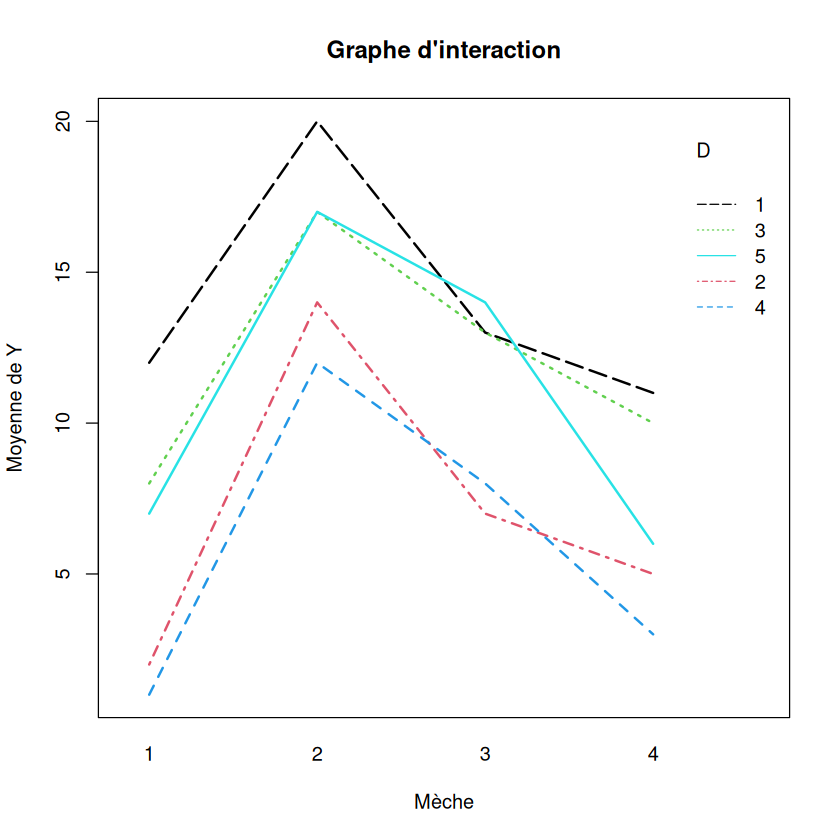

```r
interaction.plot(M, D, Y, main = "Graphe d'interaction",
                 xlab = "Mèche", ylab = "Moyenne de Y",
                 col = 1:5, lwd = 2)
```

**Interprétation :** Les lignes ne se croisent pas vraiment → l’interaction des deux facteurs influence **peu** la variable Y.

## 2.2 Table d’ANOVA sans interaction

On teste l’effet de 2 facteurs **sans** leur interaction (modèle additif) :

```r
summary(aov(Y ~ D + M))
```

```
            Df Sum Sq Mean Sq F value   Pr(>F)
D            4    184    46,0   23,00 1,49e-05 ***
M            3    310   103,3   51,67 3,91e-07 ***
Residuals   12     24     2,0
---
Signif. codes:  0 ‘***’ 0,001 ‘**’ 0,01 ‘*’ 0,05 ‘.’ 0,1 ‘ ’ 1
```

**Résultat :** Chaque facteur influence **significativement** Y.

### Avec interaction

```r
summary(aov(Y ~ D * M))
```

```
            Df Sum Sq Mean Sq
D            4    184    46,0
M            3    310   103,3
D:M         12     24     2,0
```

```r
anova(lm(Y ~ D * M))
```

A anova: 4 × 5

|  | Df <int> | Sum Sq <dbl> | Mean Sq <dbl> | F value <dbl> | Pr(>F) <dbl> |
| --- | --- | --- | --- | --- | --- |
| D | 4 | 184 | 46,0000 | NaN | NaN |
| M | 3 | 310 | 103,3333 | NaN | NaN |
| D:M | 12 | 24 | 2,0000 | NaN | NaN |
| Residuals | 0 | 0 | NaN | NA | NA |

R renvoie un message d’erreur car il n’y a pas assez de données pour estimer l’interaction de manière fiable. Cela nous conforte dans l’idée que l’interaction n’influence pas Y.

## 2.3 Attention : ANOVA à un facteur seul

Il est fondamental de noter que pris séparément, un facteur ne suffit pas à expliquer Y :

```r
cat("=== ANOVA Y ~ M ===\n")
summary(aov(Y ~ M))
cat("\n=== ANOVA Y ~ D ===\n")
summary(aov(Y ~ D))
```

```
=== ANOVA Y ~ M ===
```

```
            Df Sum Sq Mean Sq F value  Pr(>F)
M            3    310   103,3   7,949 0,00181 **
Residuals   16    208    13,0
---
Signif. codes:  0 ‘***’ 0,001 ‘**’ 0,01 ‘*’ 0,05 ‘.’ 0,1 ‘ ’ 1
```

```
=== ANOVA Y ~ D ===
```

```
            Df Sum Sq Mean Sq F value Pr(>F)
D            4    184   46,00   2,066  0,136
Residuals   15    334   22,27
```

**Observation :** Le facteur M semble expliquer Y seul, mais pas D. Pourtant, dans l’ANOVA à deux facteurs, les **deux** sont significatifs. C’est leur **action jointe** qui explique Y. Faire une ANOVA à un facteur sur ce jeu de données est une **mauvaise démarche**.

## 2.4 ANOVA avec interaction (données engrais)

Un second jeu de données avec un peu plus de données et une interaction plus marquée :

```r
engrais = read.table("engraisRegion.txt", header = TRUE)
head(engrais)
Y = engrais$Y
R = factor(engrais$R)
E = factor(engrais$E)
```

A data.frame: 6 × 3

|  | Y <int> | R <int> | E <int> |
| --- | --- | --- | --- |
| 1 | 15 | 1 | 1 |
| 2 | 14 | 1 | 1 |
| 3 | 17 | 1 | 1 |
| 4 | 21 | 2 | 1 |
| 5 | 20 | 2 | 1 |
| 6 | 21 | 2 | 1 |

### ANOVA avec interaction

```r
anova(lm(Y ~ R * E))
```

A anova: 4 × 5

|  | Df <int> | Sum Sq <dbl> | Mean Sq <dbl> | F value <dbl> | Pr(>F) <dbl> |
| --- | --- | --- | --- | --- | --- |
| R | 3 | 327,1944444 | 109,0648148 | 112,1809524 | 2,954829e-14 |
| E | 2 | 0,8888889 | 0,4444444 | 0,4571429 | 6,384893e-01 |
| R:E | 6 | 99,5555556 | 16,5925926 | 17,0666667 | 1,359421e-07 |
| Residuals | 24 | 23,3333333 | 0,9722222 | NA | NA |

**Résultat :** Seul le facteur E n’explique pas significativement Y. Par contre, R et l’interaction R:E sont significatifs.

### Sans interaction

```r
anova(lm(Y ~ R + E))
```

A anova: 3 × 5

|  | Df <int> | Sum Sq <dbl> | Mean Sq <dbl> | F value <dbl> | Pr(>F) <dbl> |
| --- | --- | --- | --- | --- | --- |
| R | 3 | 327,1944444 | 109,0648148 | 26,6252260 | 1,349547e-08 |
| E | 2 | 0,8888889 | 0,4444444 | 0,1084991 | 8,975301e-01 |
| Residuals | 30 | 122,8888889 | 4,0962963 | NA | NA |

### Graphe d’interaction

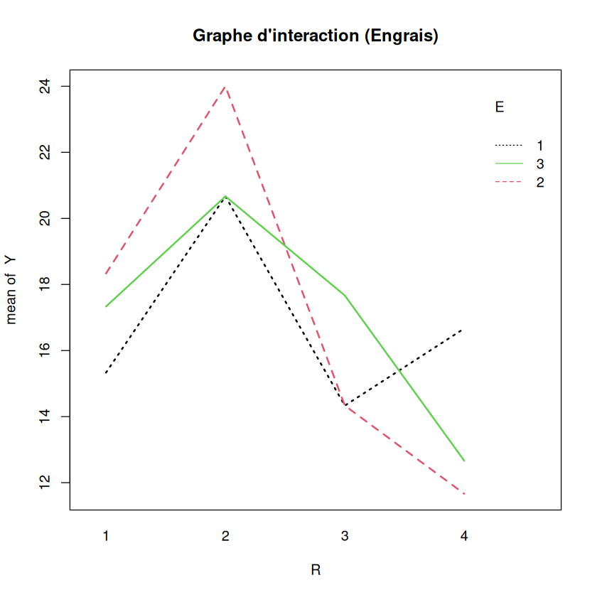

```r
interaction.plot(R, E, Y, main = "Graphe d'interaction (Engrais)",
                 col = 1:4, lwd = 2)
```

# 3. Tests non paramétriques

Les tests non paramétriques n’exigent **pas** l’hypothèse de normalité. Ils sont basés sur les **rangs** plutôt que sur les valeurs brutes.

## 3.1 Test de Wilcoxon contre Test du χ² – Round 1

### Simulation des données

```r
set.seed(42)
x = sample(1:100, 100, replace = TRUE)
quantile(x)
Q1 = quantile(x)[2]
Q3 = quantile(x)[4]
```

**0%**

2

**25%**

23,5

**50%**

48

**75%**

81,25

**100%**

100

On crée X (valeurs **extérieures** aux quartiles) et Y (valeurs **intérieures**) :

```r
X = x[x < Q1 | x > Q3]
Y = x[x > Q1 & x < Q3]

# Ajout d'aléa pour les effectifs du test χ²
X = c(X, sample(Q1:Q3, 5))
Y = c(Y, sample(1:Q1, 5), sample(Q3:100, 5))
X = sort(X)
Y = sort(Y)
```

### Test du χ²

On construit un tableau de contingence basé sur les quartiles :

```r
table_chi = rbind(c(1, 1, 1), c(1, 1, 1))
table_chi[1, 1] = length(X[X < Q1])
table_chi[1, 2] = length(X[X > Q1 & X < Q3])
table_chi[1, 3] = length(X[X > Q3])
table_chi[2, 1] = length(Y[Y < Q1])
table_chi[2, 2] = length(Y[Y > Q1 & Y < Q3])
table_chi[2, 3] = length(Y[Y > Q3])
table_chi
```

A matrix: 2 × 3 of type dbl

| 25 | 4 | 25 |
| --- | --- | --- |
| 5 | 50 | 4 |

```r
chisq.test(table_chi)
```

```
    Pearson's Chi-squared test

data:  table_chi
X-squared = 67,637, df = 2, p-value = 2,055e-15
```

**Résultat :** p-value proche de 0 → le χ² **détecte** la différence.

### Test de Wilcoxon

On classe toutes les valeurs de X et Y ensemble et on calcule la somme des rangs de X :

```r
matX = rbind(X, rep(1, length(X)))
matY = rbind(Y, rep(0, length(Y)))
matXY = cbind(matX, matY)
mat = matXY[, order(matXY[1, ])]
data_ranks = rbind(mat, 1:length(mat[1, ]))
```

```r
rang = data_ranks[3, ]
W = sum(rang[data_ranks[2, ] == 1])
cat("Statistique W =", W)
```

[output not shown]

### Conclusion du test de Wilcoxon

L’hypothèse $H_0$ d’équidistribution est rejetée au seuil $\alpha$ si :

$$\left|W - \frac{n_X(n+1)}{2}\right| > q_{\alpha/2} \sqrt{\frac{n_X n_Y (n+1)}{12}}$$

```r
U = W - length(X) * (length(X) + length(Y) + 1) / 2
pval_wilcox = 1 - pnorm(abs(U), 0, sqrt(length(X) * length(Y) * (length(X) + length(Y) + 1) / 12))
cat("p-value Wilcoxon =", pval_wilcox)
```

```
p-value Wilcoxon = 0,4754454
```

**Résultat :** Le test de Wilcoxon **ne détecte pas** la différence → Score : **χ² 1 - 0 Wilcoxon**.

## 3.2 Round 2

On redécoupe la variable x différemment :

```r
X2 = x[c(1:12, 25:36, 49:60, 73:84)]
Y2 = x[c(13:24, 37:48, 61:72, 85:96)]
```

Refaisons les deux tests :

```r
# Test χ²
table2 = rbind(c(1, 1, 1), c(1, 1, 1))
table2[1, 1] = length(X2[X2 < Q1])
table2[1, 2] = length(X2[X2 > Q1 & X2 < Q3])
table2[1, 3] = length(X2[X2 > Q3])
table2[2, 1] = length(Y2[Y2 < Q1])
table2[2, 2] = length(Y2[Y2 > Q1 & Y2 < Q3])
table2[2, 3] = length(Y2[Y2 > Q3])
chisq.test(table2)
```

```
    Pearson's Chi-squared test

data:  table2
X-squared = 4,6479, df = 2, p-value = 0,09788
```

```r
# Test de Wilcoxon (round 2)
matX2 = rbind(X2, rep(1, length(X2)))
matY2 = rbind(Y2, rep(0, length(Y2)))
matXY2 = cbind(matX2, matY2)
mat2 = matXY2[, order(matXY2[1, ])]
data2 = rbind(mat2, 1:length(mat2[1, ]))
rang2 = data2[3, ]
W2 = sum(rang2[data2[2, ] == 1])
U2 = W2 - length(X2) * (length(X2) + length(Y2) + 1) / 2
pval2 = 1 - pnorm(abs(U2), 0, sqrt(length(X2) * length(Y2) * (length(X2) + length(Y2) + 1) / 12))
cat("p-value Wilcoxon round 2 =", pval2)
```

```
p-value Wilcoxon round 2 = 0,0283781
```

**Résultat :** Cette fois, c’est le Wilcoxon qui détecte → Score : **1 partout !**

Chaque test est sensible à un type différent de différence entre distributions.

## 3.3 ANOVA contre tests non paramétriques (Ozone)

### Contexte

Étude sur la pollution de l’air : données de concentration d’ozone à Rennes durant l’été 2001. 112 observations, 13 variables.

```r
ozone = read.table("ozone.txt", sep = " ", dec = ".", header = TRUE)
head(ozone)
```

A data.frame: 6 × 13

|  | maxO3 <int> | T9 <dbl> | T12 <dbl> | T15 <dbl> | Ne9 <int> | Ne12 <int> | Ne15 <int> | Vx9 <dbl> | Vx12 <dbl> | Vx15 <dbl> | maxO3v <int> | vent <chr> | pluie <chr> |
| --- | --- | --- | --- | --- | --- | --- | --- | --- | --- | --- | --- | --- | --- |
| 20010601 | 87 | 15,6 | 18,5 | 18,4 | 4 | 4 | 8 | 0,6946 | -1,7101 | -0,6946 | 84 | Nord | Sec |
| 20010602 | 82 | 17,0 | 18,4 | 17,7 | 5 | 5 | 7 | -4,3301 | -4,0000 | -3,0000 | 87 | Nord | Sec |
| 20010603 | 92 | 15,3 | 17,6 | 19,5 | 2 | 5 | 4 | 2,9544 | 1,8794 | 0,5209 | 82 | Est | Sec |
| 20010604 | 114 | 16,2 | 19,7 | 22,5 | 1 | 1 | 0 | 0,9848 | 0,3473 | -0,1736 | 92 | Nord | Sec |
| 20010605 | 94 | 17,4 | 20,5 | 20,4 | 8 | 8 | 7 | -0,5000 | -2,9544 | -4,3301 | 114 | Ouest | Sec |
| 20010606 | 80 | 17,7 | 19,8 | 18,3 | 6 | 6 | 7 | -5,6382 | -5,0000 | -6,0000 | 94 | Ouest | Pluie |

```r
vent = ozone$vent
maxO3 = ozone$maxO3
```

### ANOVA : le vent influence-t-il l’ozone ?

```r
anova(lm(maxO3 ~ vent))
```

A anova: 2 × 5

|  | Df <int> | Sum Sq <dbl> | Mean Sq <dbl> | F value <dbl> | Pr(>F) <dbl> |
| --- | --- | --- | --- | --- | --- |
| vent | 3 | 7586,057 | 2528,6855 | 3,388077 | 0,02073516 |
| Residuals | 108 | 80605,622 | 746,3484 | NA | NA |

On aurait tendance à penser que le vent influence significativement la concentration en ozone.

### Test de normalité par groupe

Il est **indispensable** de vérifier la normalité pour valider l’ANOVA :

```r
tapply(maxO3, vent, shapiro.test)
```

```
$Est

    Shapiro-Wilk normality test

data:  X[[i]]
W = 0,91843, p-value = 0,344


$Nord

    Shapiro-Wilk normality test

data:  X[[i]]
W = 0,87595, p-value = 0,001906


$Ouest

    Shapiro-Wilk normality test

data:  X[[i]]
W = 0,7954, p-value = 6,881e-07


$Sud

    Shapiro-Wilk normality test

data:  X[[i]]
W = 0,95172, p-value = 0,367
```

**Problème :** Certains échantillons ne sont **pas gaussiens** → on devrait éviter l’ANOVA !

### Test de Kruskal-Wallis (alternative non paramétrique)

Le test de Kruskal-Wallis est un analogue de l’ANOVA, mais **sans hypothèse de normalité**. Il est basé sur les rangs.

```r
kruskal.test(maxO3 ~ vent)
```

```
    Kruskal-Wallis rank sum test

data:  maxO3 by vent
Kruskal-Wallis chi-squared = 13,645, df = 3, p-value = 0,003431
```

**Résultat :** Même conclusion (le vent influence l’ozone), avec une p-value encore plus faible.

### Test de corrélation de rang de Spearman

On se demande si la température et la composante E-O du vent à 9h sont indépendantes :

```r
Vx9 = ozone$Vx9
T9 = ozone$T9
```

#### À la main

La statistique est le coefficient de corrélation des **rangs** :

```r
Rstar = cor(rank(Vx9), rank(T9))
cat("Corrélation de Spearman R* =", round(Rstar, 4))
```

```
Corrélation de Spearman R* = 0,2314
```

On compare `|R*|` au quantile $q_{0.975}$ de $\mathcal{N}(0, \sqrt{1/(n-1)})$ :

```r
seuil = qnorm(0.975, 0, sqrt(1 / (length(T9) - 1)))
cat("Seuil critique =", round(seuil, 4))
cat("\n|R*| =", round(abs(Rstar), 4))
cat("\nRejet ?", abs(Rstar) > seuil)
```

```
Seuil critique = 0,186
|R*| = 0,2314
Rejet ? TRUE
```

#### Avec la fonction R

```r
cor.test(Vx9, T9, method = "spearman")
```

```
    Spearman's rank correlation rho

data:  Vx9 and T9
S = 179954, p-value = 0,01409
alternative hypothesis: true rho is not equal to 0
sample estimates:
      rho
0,2314122
```

**Conclusion :** On rejette l’hypothèse de nullité de la corrélation → les variables sont **dépendantes**.

# Résumé

| Test | Hypothèse de normalité | Utilisation | Fonction R |
| --- | --- | --- | --- |
| ANOVA (Fisher) | Oui | Comparer les moyennes de k groupes | `anova(lm())` |
| Kruskal-Wallis | Non | Alternative à l’ANOVA | `kruskal.test()` |
| Wilcoxon | Non | Comparer 2 échantillons | Calcul manuel |
| χ² d’adéquation | Non | Comparer des distributions | `chisq.test()` |
| Spearman | Non | Tester l’indépendance (corrélation de rangs) | `cor.test(method="spearman")` |

**Points clés :**

- Toujours vérifier la **normalité** avant d’utiliser l’ANOVA.
- Les tests non paramétriques sont des alternatives robustes.
- Différents tests détectent différents types de différences entre distributions.
- L’ANOVA à deux facteurs capture l’effet **conjoint** de deux facteurs, ce qu’une ANOVA à un facteur ne peut pas faire.